# The Predictor (Capstone)

Mohib

5/10/2020

# Task at Hand:

This app, namely ‘The Predictor’ was designed as part of the Capstone Project of Data Specializtion provided by John Hopkins University on Coursera.

Typing entire sentences on phones and other smart devices can be an arduous task, consequenctly, it can be very helpful to have the next possible word provided to you without you having to type it. This was the problem at hand, to design a word prediction algorithm and then to integrate into a data product which could be easily accessible,

The dataset provided for this consisted of three large files from twitter, blogs and news articles which was to be utilized for the design of the app.

# Possible Techniques

The prediction algorithm can be designed by a large number of techniques with varying accuracy and processing time. Some of the techniques include:

- Katz-Back Off
- Keyser Ney
- Nueral Networking

# Katz-Off Model:

For the design of this app, katz back off model was used alongwith Good-Turing Smoothing. To understand it broadly, it generates the conditional probablity of a word given its history in an n-gram language model. It accomplishes this by backing off through shorter models if the result is not found in one of the larger models. Ultimately, it displays the word given the history for an accurate prediction. The link to wikipedia can further be used to understand the method [Katz-Back Off Model](https://en.wikipedia.org/wiki/Katz%27s_back-off_model).

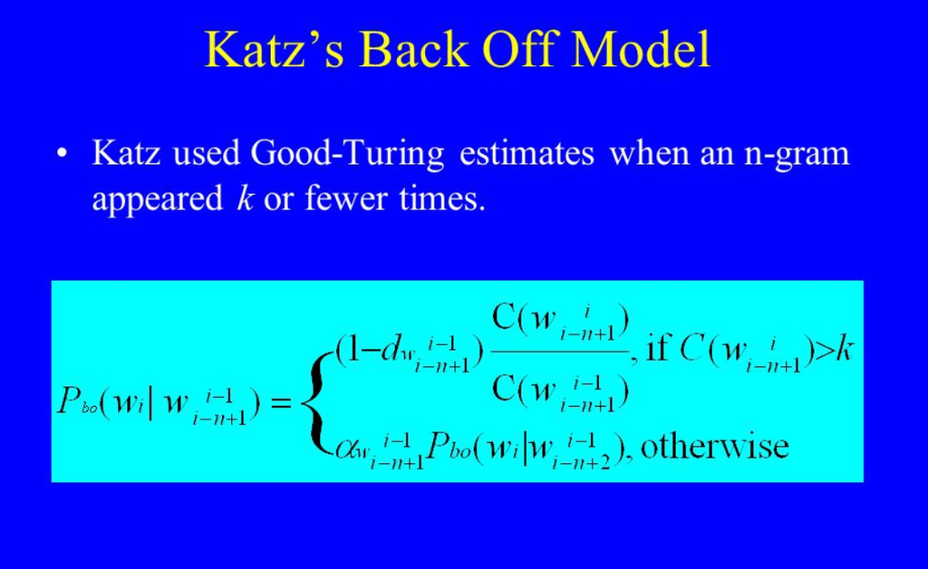

# User Interface:

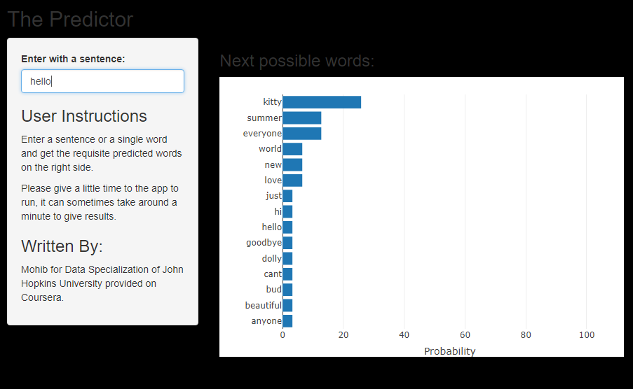

Sources: [Katz-Back Off Model](https://en.wikipedia.org/wiki/Katz%27s_back-off_model) ; [Prediction Model](https://github.com/schmittjoaopedro/data-science-capstone/blob/master/project/WordPredicting/predictor.R) ; [NLP](https://pdfs.semanticscholar.org/d461/b48b93567814caaa1589190f6249e394bf05.pdf). Other books were also utilized to understand the concept.